# Market Analysis for Target Global

Autores: Graciela Rivera, Luis E. Vargas Porras

[figure not shown]

# 1 Fase del entendimiento de negocio:

## 1.1 Objetivo y criterio de Negocio

### 1.1.1 Objetivo

Identificar aquellas transacciones de órdenes de compra de Target Global que sean altamente asociadas entre ellas con el fin de aumentar las promociones de estos productos para el Q1, 2023 y sirva de información para el motor de recomendación de su tienda online.

### 1.1.2 Criterio de Negocio

1. Aumentar en un 3% las promociones de los productos que tenga una fuerte asociación para el próximo Q3, 2023.
2. Aumentar las ventas del negocio en 5% para el próximo Q3, 2023, y un 7% para el Q4, 2023 respectivamente.

## 1.2 Objetivo y criterio de Minería de Datos

### 1.2.1 Objetivo

Desarrollar un modelo algorítmico A priori para identificar la fuerza de asociación entre los productos de la tienda Online Target Global.

### 1.2.2 Criterios de éxito (desde la perspectiva de minería de datos).

# 2 Entendimiento de los Datos

- Carga Inicial del Data Set Online Retail para el informe inicial de Datos.

```r
#Librerías
library(DT)
library(dplyr)
```

```r
library(ggplot2)
library(knitr)
library(arules)
library(arulesViz)
library(plyr)
EcommerceData <- read.csv("EcommerceData.csv")
head(EcommerceData)
```

```
##   InvoiceNo StockCode                         Description Quantity
## 1    536365    85123A  WHITE HANGING HEART T-LIGHT HOLDER        6
## 2    536365     71053                 WHITE METAL LANTERN        6
## 3    536365    84406B      CREAM CUPID HEARTS COAT HANGER        8
## 4    536365    84029G KNITTED UNION FLAG HOT WATER BOTTLE        6
## 5    536365    84029E      RED WOOLLY HOTTIE WHITE HEART.        6
## 6    536365     22752        SET 7 BABUSHKA NESTING BOXES        2
##      InvoiceDate UnitPrice CustomerID        Country
## 1 12/1/2010 8:26      2.55      17850 United Kingdom
## 2 12/1/2010 8:26      3.39      17850 United Kingdom
## 3 12/1/2010 8:26      2.75      17850 United Kingdom
## 4 12/1/2010 8:26      3.39      17850 United Kingdom
## 5 12/1/2010 8:26      3.39      17850 United Kingdom
## 6 12/1/2010 8:26      7.65      17850 United Kingdom
```

```r
#View(EcommerceData)
```

- Descripción del Data Set ” Online Retail”

El data set cuenta con las siguientes estructura de columnas.

```r
head(EcommerceData,10)
```

```
##    InvoiceNo StockCode                         Description Quantity
## 1     536365    85123A  WHITE HANGING HEART T-LIGHT HOLDER        6
## 2     536365     71053                 WHITE METAL LANTERN        6
## 3     536365    84406B      CREAM CUPID HEARTS COAT HANGER        8
## 4     536365    84029G KNITTED UNION FLAG HOT WATER BOTTLE        6
## 5     536365    84029E      RED WOOLLY HOTTIE WHITE HEART.        6
## 6     536365     22752        SET 7 BABUSHKA NESTING BOXES        2
## 7     536365     21730   GLASS STAR FROSTED T-LIGHT HOLDER        6
## 8     536366     22633              HAND WARMER UNION JACK        6
## 9     536366     22632           HAND WARMER RED POLKA DOT        6
## 10    536367     84879       ASSORTED COLOUR BIRD ORNAMENT       32
##       InvoiceDate UnitPrice CustomerID        Country
## 1  12/1/2010 8:26      2.55      17850 United Kingdom
## 2  12/1/2010 8:26      3.39      17850 United Kingdom
## 3  12/1/2010 8:26      2.75      17850 United Kingdom
## 4  12/1/2010 8:26      3.39      17850 United Kingdom
## 5  12/1/2010 8:26      3.39      17850 United Kingdom
## 6  12/1/2010 8:26      7.65      17850 United Kingdom
## 7  12/1/2010 8:26      4.25      17850 United Kingdom
## 8  12/1/2010 8:28      1.85      17850 United Kingdom
## 9  12/1/2010 8:28      1.85      17850 United Kingdom
## 10 12/1/2010 8:34      1.69      13047 United Kingdom
```

En cuanto al numero de registros se tienen 541909 observaciones con ocho variables

```r
str(EcommerceData)
```

```
## 'data.frame':    541909 obs. of  8 variables:
##  $ InvoiceNo  : chr  "536365" "536365" "536365" "536365" ...
##  $ StockCode  : chr  "85123A" "71053" "84406B" "84029G" ...
##  $ Description: chr  "WHITE HANGING HEART T-LIGHT HOLDER" "WHITE METAL LANTERN" "CREAM CUPID HEARTS COAT HANGER" "KNITTED UNION FLAG HOT WATER BOTTLE" ...
##  $ Quantity   : int  6 6 8 6 6 2 6 6 6 32 ...
##  $ InvoiceDate: chr  "12/1/2010 8:26" "12/1/2010 8:26" "12/1/2010 8:26" "12/1/2010 8:26" ...
##  $ UnitPrice  : num  2.55 3.39 2.75 3.39 3.39 7.65 4.25 1.85 1.85 1.69 ...
##  $ CustomerID : int  17850 17850 17850 17850 17850 17850 17850 17850 17850 13047 ...
##  $ Country    : chr  "United Kingdom" "United Kingdom" "United Kingdom" "United Kingdom" ...
```

Para tener un resumen descriptivo estadístico de nuestro data set, usamos la función *summary()* el cual nos da el siguiente resultado:

```r
summary(EcommerceData)
```

```
##   InvoiceNo          StockCode         Description           Quantity
##  Length:541909      Length:541909      Length:541909      Min.   :-80995.00
##  Class :character   Class :character   Class :character   1st Qu.:     1.00
##  Mode  :character   Mode  :character   Mode  :character   Median :     3.00
##                                                           Mean   :     9.55
##                                                           3rd Qu.:    10.00
##                                                           Max.   : 80995.00
##
##  InvoiceDate          UnitPrice           CustomerID       Country
##  Length:541909      Min.   :-11062.06   Min.   :12346    Length:541909
##  Class :character   1st Qu.:     1.25   1st Qu.:13953    Class :character
##  Mode  :character   Median :     2.08   Median :15152    Mode  :character
##                     Mean   :     4.61   Mean   :15288
##                     3rd Qu.:     4.13   3rd Qu.:16791
##                     Max.   : 38970.00   Max.   :18287
##                                         NA's   :135080
```

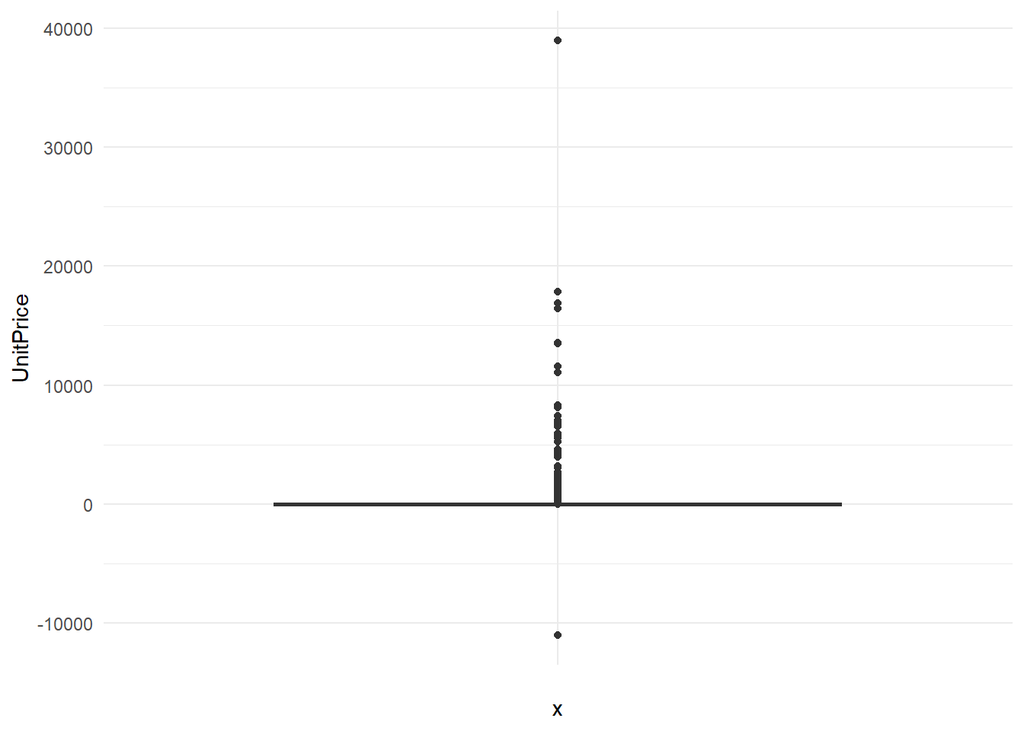

```r
ggplot(EcommerceData) +
  aes(x = "", y = UnitPrice) +
  geom_boxplot(fill = "#0c4c8a") +
  theme_minimal()
```

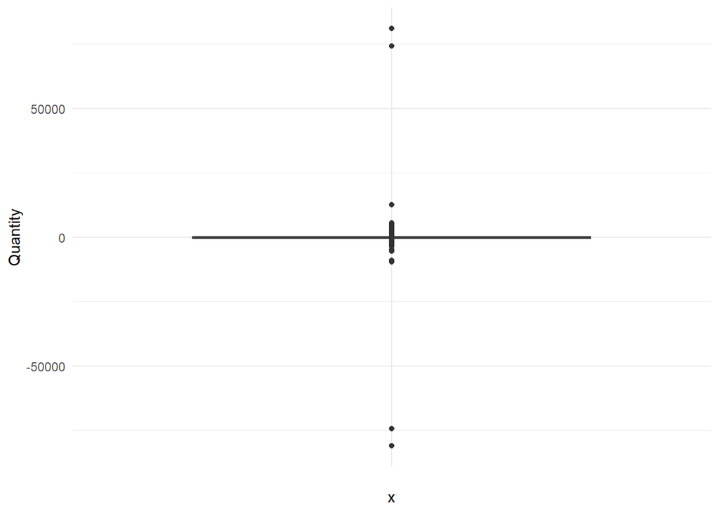

```r
ggplot(EcommerceData) +
  aes(x = "", y = Quantity) +
  geom_boxplot(fill = "#0c4c8a") +
  theme_minimal()
```

Se puede observar que el Data set contiene un total de `541909` filas (transacciones), y cuenta con `ocho` atributos. Además se tienen datos tipo numérico y strings(cadenas).

En cuanto a la calidad de datos, se puede observar que:

1. la columna CustomerID contiene `135080 NA's`, por lo que se deben de eliminar para evitar tener ruido y aumentar la consistencia en los resultados cuando se efectúe el modelo.
2. La columna de fecha **InvoiceDate** es de tipo texto, y queremos que ésta sea de tipo `date`.
3. Para aquellas transacciones que fueron canceladas o devueltas, se identifican con la letra “c” dentro del campo de *InvoiceNo* y por esta razón hay cantidades negativas en la columna “Quantity”, las cual se deben de eliminar para el análisis.
4. Hay records que no necesariamentes son transacciones de productos, sino que se registran cuentas bancarias, fees, devoluciones etc. Lo anterior se puede ver en la columna de *StockCodes* ejemplos códigos D,M,S que representa “Discounts, Manual Imput, Sample.
5. Se tienen precios (UnitPrice) negativos y algunos registros tiene 0, y en la columna de *Descripción* hay registros que estan vacíos.
6. No existe una métrica de ventas dentro del data set, sin embargo se tienen los campos para poder calcularla para nuestro análisis.

*Este preprocesamiento, se realiza en la “Fase de Preparación”*

Para este momento, conviene realizar una exploración de los datos inicial que ayuden a encontrar nuestros principales hallazgos e hipotésis, donde podríamos llegar a conclusiones que será validadas en los resultados finales. Se hace uso de Tableu para la visualización que incluye plots y gráficos que qyuden a mostrar las características y sugerir/descubrir tendencias interesantes que podrían tener los datos.

[Tableau Proyecto Final](https://public.tableau.com/app/profile/luis.enrique.vargas/viz/ProyectoFinal_16801552299020/Dashboard1)

# 3 Preparación de los datos

## 3.1 Cambiar el tipo de dato a Date

```r
#datosEcommerce$InvoiceDate <- as.POSIXct(datosEcommerce$InvoiceDate, format="%m/%d/%Y %H:%M")
EcommerceData$InvoiceDate <- as.Date(EcommerceData$InvoiceDate, format="%m/%d/%Y")
str(EcommerceData)
```

```
## 'data.frame':    541909 obs. of  8 variables:
##  $ InvoiceNo  : chr  "536365" "536365" "536365" "536365" ...
##  $ StockCode  : chr  "85123A" "71053" "84406B" "84029G" ...
##  $ Description: chr  "WHITE HANGING HEART T-LIGHT HOLDER" "WHITE METAL LANTERN" "CREAM CUPID HEARTS COAT HANGER" "KNITTED UNION FLAG HOT WATER BOTTLE" ...
##  $ Quantity   : int  6 6 8 6 6 2 6 6 6 32 ...
##  $ InvoiceDate: Date, format: "2010-12-01" "2010-12-01" ...
##  $ UnitPrice  : num  2.55 3.39 2.75 3.39 3.39 7.65 4.25 1.85 1.85 1.69 ...
##  $ CustomerID : int  17850 17850 17850 17850 17850 17850 17850 17850 17850 13047 ...
##  $ Country    : chr  "United Kingdom" "United Kingdom" "United Kingdom" "United Kingdom" ...
```

## 3.2 Creación de una nueva métrica

```r
EcommerceData$Sales <- EcommerceData$Quantity * EcommerceData$UnitPrice
str(EcommerceData)
```

```
## 'data.frame':    541909 obs. of  9 variables:
##  $ InvoiceNo  : chr  "536365" "536365" "536365" "536365" ...
##  $ StockCode  : chr  "85123A" "71053" "84406B" "84029G" ...
##  $ Description: chr  "WHITE HANGING HEART T-LIGHT HOLDER" "WHITE METAL LANTERN" "CREAM CUPID HEARTS COAT HANGER" "KNITTED UNION FLAG HOT WATER BOTTLE" ...
##  $ Quantity   : int  6 6 8 6 6 2 6 6 6 32 ...
##  $ InvoiceDate: Date, format: "2010-12-01" "2010-12-01" ...
##  $ UnitPrice  : num  2.55 3.39 2.75 3.39 3.39 7.65 4.25 1.85 1.85 1.69 ...
##  $ CustomerID : int  17850 17850 17850 17850 17850 17850 17850 17850 17850 13047 ...
##  $ Country    : chr  "United Kingdom" "United Kingdom" "United Kingdom" "United Kingdom" ...
##  $ Sales      : num  15.3 20.3 22 20.3 20.3 ...
```

## 3.3 Eliminar NA’s

```r
EcommerceData <- na.omit(EcommerceData)
summary(EcommerceData)
```

```
##   InvoiceNo          StockCode         Description           Quantity
##  Length:406829      Length:406829      Length:406829      Min.   :-80995.00
##  Class :character   Class :character   Class :character   1st Qu.:     2.00
##  Mode  :character   Mode  :character   Mode  :character   Median :     5.00
##                                                           Mean   :    12.06
##                                                           3rd Qu.:    12.00
##                                                           Max.   : 80995.00
##   InvoiceDate           UnitPrice          CustomerID      Country
##  Min.   :2010-12-01   Min.   :    0.00   Min.   :12346   Length:406829
##  1st Qu.:2011-04-06   1st Qu.:    1.25   1st Qu.:13953   Class :character
##  Median :2011-07-31   Median :    1.95   Median :15152   Mode  :character
##  Mean   :2011-07-10   Mean   :    3.46   Mean   :15288
##  3rd Qu.:2011-10-20   3rd Qu.:    3.75   3rd Qu.:16791
##  Max.   :2011-12-09   Max.   :38970.00   Max.   :18287
##      Sales
##  Min.   :-168469.6
##  1st Qu.:      4.2
##  Median :     11.1
##  Mean   :     20.4
##  3rd Qu.:     19.5
##  Max.   : 168469.6
```

## 3.4 Eliminar ventas negativas.

```r
EcommerceData <- EcommerceData[EcommerceData$Sales > 0, ]
summary(EcommerceData)
```

```
##   InvoiceNo          StockCode         Description           Quantity
##  Length:397884      Length:397884      Length:397884      Min.   :    1.00
##  Class :character   Class :character   Class :character   1st Qu.:    2.00
##  Mode  :character   Mode  :character   Mode  :character   Median :    6.00
##                                                           Mean   :   12.99
##                                                           3rd Qu.:   12.00
##                                                           Max.   :80995.00
##   InvoiceDate           UnitPrice          CustomerID      Country
##  Min.   :2010-12-01   Min.   :   0.001   Min.   :12346   Length:397884
##  1st Qu.:2011-04-07   1st Qu.:   1.250   1st Qu.:13969   Class :character
##  Median :2011-07-31   Median :   1.950   Median :15159   Mode  :character
##  Mean   :2011-07-10   Mean   :   3.116   Mean   :15294
##  3rd Qu.:2011-10-20   3rd Qu.:   3.750   3rd Qu.:16795
##  Max.   :2011-12-09   Max.   :8142.750   Max.   :18287
##      Sales
##  Min.   :     0.00
##  1st Qu.:     4.68
##  Median :    11.80
##  Mean   :    22.40
##  3rd Qu.:    19.80
##  Max.   :168469.60
```

## 3.5 Eliminar excepciones de *StockCode*

```r
EcommerceData <- EcommerceData[-which(EcommerceData$StockCode == 'POST'),]
summary(EcommerceData)
```

```
##   InvoiceNo          StockCode         Description           Quantity
##  Length:396785      Length:396785      Length:396785      Min.   :    1.00
##  Class :character   Class :character   Class :character   1st Qu.:    2.00
##  Mode  :character   Mode  :character   Mode  :character   Median :    6.00
##                                                           Mean   :   13.02
##                                                           3rd Qu.:   12.00
##                                                           Max.   :80995.00
##   InvoiceDate           UnitPrice          CustomerID      Country
##  Min.   :2010-12-01   Min.   :   0.001   Min.   :12346   Length:396785
##  1st Qu.:2011-04-07   1st Qu.:   1.250   1st Qu.:13975   Class :character
##  Median :2011-07-31   Median :   1.950   Median :15159   Mode  :character
##  Mean   :2011-07-10   Mean   :   3.038   Mean   :15301
##  3rd Qu.:2011-10-20   3rd Qu.:   3.750   3rd Qu.:16801
##  Max.   :2011-12-09   Max.   :4161.060   Max.   :18287
##      Sales
##  Min.   :     0.00
##  1st Qu.:     4.68
##  Median :    11.80
##  Mean   :    22.26
##  3rd Qu.:    19.80
##  Max.   :168469.60
```

```r
EcommerceData <- EcommerceData %>% filter(!StockCode %in% c('S','M'))
summary(EcommerceData)
```

```
##   InvoiceNo          StockCode         Description           Quantity
##  Length:396501      Length:396501      Length:396501      Min.   :    1.00
##  Class :character   Class :character   Class :character   1st Qu.:    2.00
##  Mode  :character   Mode  :character   Mode  :character   Median :    6.00
##                                                           Mean   :   13.01
##                                                           3rd Qu.:   12.00
##                                                           Max.   :80995.00
##   InvoiceDate           UnitPrice          CustomerID      Country
##  Min.   :2010-12-01   Min.   :   0.001   Min.   :12346   Length:396501
##  1st Qu.:2011-04-07   1st Qu.:   1.250   1st Qu.:13975   Class :character
##  Median :2011-07-31   Median :   1.950   Median :15159   Mode  :character
##  Mean   :2011-07-10   Mean   :   2.914   Mean   :15301
##  3rd Qu.:2011-10-20   3rd Qu.:   3.750   3rd Qu.:16801
##  Max.   :2011-12-09   Max.   :1599.260   Max.   :18287
##      Sales
##  Min.   :     0.00
##  1st Qu.:     4.68
##  Median :    11.80
##  Mean   :    22.14
##  3rd Qu.:    19.80
##  Max.   :168469.60
```

```r
EcommerceData <- EcommerceData[-which(EcommerceData$StockCode == 'BANK CHARGES'),]
summary(EcommerceData)
```

```
##   InvoiceNo          StockCode         Description           Quantity
##  Length:396489      Length:396489      Length:396489      Min.   :    1.00
##  Class :character   Class :character   Class :character   1st Qu.:    2.00
##  Mode  :character   Mode  :character   Mode  :character   Median :    6.00
##                                                           Mean   :   13.01
##                                                           3rd Qu.:   12.00
##                                                           Max.   :80995.00
##   InvoiceDate           UnitPrice          CustomerID      Country
##  Min.   :2010-12-01   Min.   :   0.001   Min.   :12346   Length:396489
##  1st Qu.:2011-04-07   1st Qu.:   1.250   1st Qu.:13975   Class :character
##  Median :2011-07-31   Median :   1.950   Median :15159   Mode  :character
##  Mean   :2011-07-10   Mean   :   2.914   Mean   :15301
##  3rd Qu.:2011-10-20   3rd Qu.:   3.750   3rd Qu.:16801
##  Max.   :2011-12-09   Max.   :1599.260   Max.   :18287
##      Sales
##  Min.   :     0.00
##  1st Qu.:     4.68
##  Median :    11.80
##  Mean   :    22.14
##  3rd Qu.:    19.80
##  Max.   :168469.60
```

```r
 # se guardan los datos limpios en archivo csv para visualizar en tableau
write.csv(EcommerceData,'EcommerceDataCleaned.csv', quote = FALSE)
```

# 4 Modelado de los datos

- Modelo de Apriori

Este algoritmo se utiliza sobre bases de datos transaccionales, y permite encontrar de forma eficiente “conjunto de items frecuentes”, los cuales sirven de base para generar reglas de asociación. Usualmente se recomienda para bases de datos grandes.

- Modelo de Eclat

ECLAT significa “Equivalence Class Clustering and bottom-up Lattice Traversal”. Al igual que el algoritmo de Aproiri es otro método popular de reglas de asociación usado en minería de datos. Es una versión mas eficiente y escalable que el algoritmo de Apriori. Mientras que el algoritmo de Apriori trabaja en el sentido horizontal imitando la búsqueda de Breadth-First en una estructura de árbol, el ECLAT trabaja en el sentido vertical como la búsqueda de Depth-First. Usualmente se recomienda para bases de datos pequeñas y medianas.

## 4.1 Conversión de los datos originales a formato transaccional

```r
# recordar de activar el paquete plyr
# se agrupan las transacciones con igual InvoiceNo y InvoiceDate
# luego se concatena con una coma
EcommerceTransactions<- ddply(EcommerceData,c('InvoiceNo','InvoiceDate'),
                     function(dataf) paste(dataf$Description,collapse = ','))

# se descartan la fecha y el # de facturas para las reglas de asociación
EcommerceTransactions$InvoiceNo<-NULL
EcommerceTransactions$InvoiceDate<-NULL

# se renombra la columna restante como items
colnames(EcommerceTransactions) <- c('Items')

# se guardan los datos como archivo csv en formato transaccion
write.csv(EcommerceTransactions,'EcommerceTransactions.csv', quote = FALSE)
```

## 4.2 Lectura de los datos en formato transacción

```r
# Recordar de activar el paquete arules
# se remueve los items duplicados también
TransactionsLoaded <- read.transactions('EcommerceTransactions.csv',sep=',',format = 'basket', quote = "", rm.duplicates = 1)
```

```
## distribution of transactions with duplicates:
## items
##    1    2    3    4    5    6    7    8    9   10   11   12   13   14   15   16
## 1081  549  314  217  144  116  104   61   47   45   34   28   30   12   10    9
##   17   18   19   20   21   22   23   24   25   26   27   28   29   30   31   32
##   18    9    7    3    1    3    3    6    2    5    3    2    3    3    1    1
##   33   34   36   37   42   45   46   50   52
##    1    1    1    1    1    1    1    1    1
```

## 4.3 Exploración de las transacciones

```r
# formato actual de tabla de transacciones
inspect(TransactionsLoaded[1:5])
```

```
##     items
## [1] {Items}
## [2] {1,
##      CREAM CUPID HEARTS COAT HANGER,
##      GLASS STAR FROSTED T-LIGHT HOLDER,
##      KNITTED UNION FLAG HOT WATER BOTTLE,
##      RED WOOLLY HOTTIE WHITE HEART.,
##      SET 7 BABUSHKA NESTING BOXES,
##      WHITE HANGING HEART T-LIGHT HOLDER,
##      WHITE METAL LANTERN}
## [3] {2,
##      HAND WARMER RED POLKA DOT,
##      HAND WARMER UNION JACK}
## [4] {3,
##      ASSORTED COLOUR BIRD ORNAMENT,
##      BOX OF 6 ASSORTED COLOUR TEASPOONS,
##      BOX OF VINTAGE ALPHABET BLOCKS,
##      BOX OF VINTAGE JIGSAW BLOCKS,
##      DOORMAT NEW ENGLAND,
##      FELTCRAFT PRINCESS CHARLOTTE DOLL,
##      HOME BUILDING BLOCK WORD,
##      IVORY KNITTED MUG COSY,
##      LOVE BUILDING BLOCK WORD,
##      POPPY'S PLAYHOUSE BEDROOM,
##      POPPY'S PLAYHOUSE KITCHEN,
##      RECIPE BOX WITH METAL HEART}
## [5] {4,
##      BLUE COAT RACK PARIS FASHION,
##      JAM MAKING SET WITH JARS,
##      RED COAT RACK PARIS FASHION,
##      YELLOW COAT RACK PARIS FASHION}
```

```r
# recordar aplicar el paquete tidyverse
TibbleTransactions <- as(TransactionsLoaded, Class = "data.frame")

# se convierte el dataframe a tibble para visualizar mejor tabla de datos,
# sin embargo se sigue usando "TransactionsLoaded" para el resto del análisis
as_tibble(TibbleTransactions) %>% head(10)
```

```
## # A tibble: 10 × 1
##    items
##    <chr>
##  1 {Items}
##  2 {1,CREAM CUPID HEARTS COAT HANGER,GLASS STAR FROSTED T-LIGHT HOLDER,KNITTED …
##  3 {2,HAND WARMER RED POLKA DOT,HAND WARMER UNION JACK}
##  4 {3,ASSORTED COLOUR BIRD ORNAMENT,BOX OF 6 ASSORTED COLOUR TEASPOONS,BOX OF V…
##  5 {4,BLUE COAT RACK PARIS FASHION,JAM MAKING SET WITH JARS,RED COAT RACK PARIS…
##  6 {5,BATH BUILDING BLOCK WORD}
##  7 {6,ALARM CLOCK BAKELIKE GREEN,ALARM CLOCK BAKELIKE PINK,ALARM CLOCK BAKELIKE…
##  8 {7,PAPER CHAIN KIT 50'S CHRISTMAS}
##  9 {8,HAND WARMER RED POLKA DOT,HAND WARMER UNION JACK}
## 10 {9,CREAM CUPID HEARTS COAT HANGER,EDWARDIAN PARASOL RED,GLASS STAR FROSTED T…
```

## 4.4 Resumen de las transacciones

```r
summary(TransactionsLoaded)
```

```
## transactions as itemMatrix in sparse format with
##  18406 rows (elements/itemsets/transactions) and
##  22309 columns (items) and a density of 0.0009918234
##
## most frequent items:
## WHITE HANGING HEART T-LIGHT HOLDER           REGENCY CAKESTAND 3 TIER
##                               1971                               1703
##            JUMBO BAG RED RETROSPOT                      PARTY BUNTING
##                               1600                               1379
##      ASSORTED COLOUR BIRD ORNAMENT                            (Other)
##                               1375                             399234
##
## element (itemset/transaction) length distribution:
## sizes
##    1    2    3    4    5    6    7    8    9   10   11   12   13   14   15   16
##    1 1307  720  641  636  645  592  569  583  626  525  530  504  465  505  549
##   17   18   19   20   21   22   23   24   25   26   27   28   29   30   31   32
##  534  448  448  480  411  410  340  330  292  243  261  246  227  261  232  183
##   33   34   35   36   37   38   39   40   41   42   43   44   45   46   47   48
##  176  164  166  145  113  136  104  125  121  110  103   98   89   86   87   84
##   49   50   51   52   53   54   55   56   57   58   59   60   61   62   63   64
##   76   77   70   62   60   64   66   59   54   48   45   50   40   39   35   34
##   65   66   67   68   69   70   71   72   73   74   75   76   77   78   79   80
##   30   33   38   39   34   21   29   29   15   26   33   24   19   18   17   12
##   81   82   83   84   85   86   87   88   89   90   91   92   93   94   95   96
##   14   18   18   17   19   14   11   14   13    8   10   10   16   10    9    5
##   97   98   99  100  101  102  103  104  105  106  107  108  109  110  111  112
##    8   12    9    4    9   10    6    8    5    2    3    3    6    4    3    3
##  113  114  115  116  117  118  119  120  121  122  123  124  125  126  127  128
##    2    5    4    5    6    5    5    5    6    5    7    4    1    4    5    3
##  129  130  131  133  134  135  136  137  138  140  141  142  143  144  145  147
##    4    1    1    1    4    1    2    2    4    1    2    3    1    2    1    5
##  149  150  152  155  158  159  160  165  168  170  171  172  178  179  181  182
##    1    2    3    1    1    1    1    2    1    1    1    1    3    1    2    1
##  185  187  194  195  197  205  206  209  212  221  231  251  260  264  274  284
##    1    1    1    1    1    1    1    1    1    1    1    1    1    1    1    1
##  340  352  357  367  380  387  423  441  443  530  534  548
##    1    1    1    1    1    1    1    1    1    1    1    1
##
##    Min. 1st Qu.  Median    Mean 3rd Qu.    Max.
##    1.00    8.00   16.00   22.13   28.00  548.00
##
## includes extended item information - examples:
##     labels
## 1        1
## 2 1 HANGER
## 3       10
```

## 4.5 Determinar los items más frecuentes

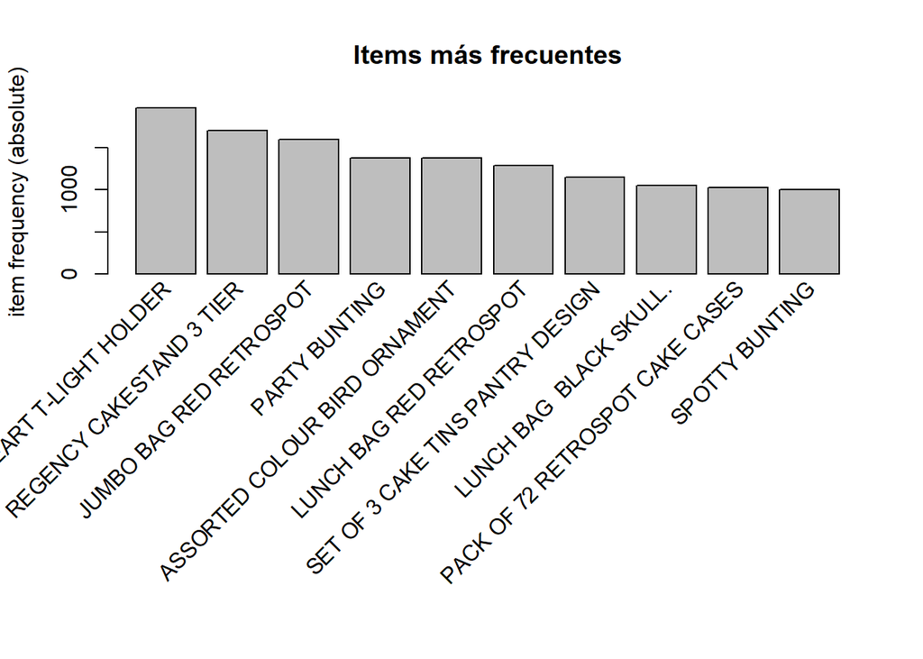

```r
itemFrequencyPlot(TransactionsLoaded,topN=10,type='absolute',main="Items más frecuentes")
```

## 4.7 Generación de reglas para cada modelo

```r
eclatItemsets <- eclat(TransactionsLoaded, parameter=list(supp=0.005, maxlen=10))
```

```
## Eclat
##
## parameter specification:
##  tidLists support minlen maxlen            target  ext
##     FALSE   0.005      1     10 frequent itemsets TRUE
##
## algorithmic control:
##  sparse sort verbose
##       7   -2    TRUE
##
## Absolute minimum support count: 92
##
## create itemset ...
## set transactions ...[22309 item(s), 18406 transaction(s)] done [0.13s].
## sorting and recoding items ... [1255 item(s)] done [0.01s].
## creating sparse bit matrix ... [1255 row(s), 18406 column(s)] done [0.00s].
## writing  ... [4066 set(s)] done [0.82s].
## Creating S4 object  ... done [0.00s].
```

```r
tmpEclatRules <- ruleInduction(eclatItemsets, confidence = 0.85)

# eliminar reglas que son subconjuntos de otras
eclatSubconjuntos<- which(colSums(is.subset(tmpEclatRules,tmpEclatRules))>1)
eclatRules<- tmpEclatRules[-eclatSubconjuntos]

#inspect(eclatRules[1:10])
# Ordena items de acuerdo al soporte
inspect(sort(eclatRules,by='support',decreasing = TRUE)[1:20])
```

```
##      lhs                                       rhs                                      support confidence     lift
## [1]  {PINK REGENCY TEACUP AND SAUCER,
##       ROSES REGENCY TEACUP AND SAUCER}      => {GREEN REGENCY TEACUP AND SAUCER}    0.021188743  0.8944954 23.82646
## [2]  {PINK REGENCY TEACUP AND SAUCER,
##       REGENCY CAKESTAND 3 TIER}             => {GREEN REGENCY TEACUP AND SAUCER}    0.014723460  0.8770227 23.36104
## [3]  {SHED}                                 => {KEY FOB}                            0.014397479  1.0000000 49.08267
## [4]  {PINK REGENCY TEACUP AND SAUCER,
##       REGENCY CAKESTAND 3 TIER}             => {ROSES REGENCY TEACUP AND SAUCER}    0.014397479  0.8576052 20.15975
## [5]  {SET 3 RETROSPOT TEA}                  => {COFFEE}                             0.013093556  1.0000000 57.69906
## [6]  {SUGAR}                                => {COFFEE}                             0.013093556  1.0000000 57.69906
## [7]  {BACK DOOR}                            => {KEY FOB}                            0.012713246  1.0000000 49.08267
## [8]  {POPPY'S PLAYHOUSE LIVINGROOM}         => {POPPY'S PLAYHOUSE KITCHEN}          0.011680974  0.8531746 45.38593
## [9]  {REGENCY TEA PLATE PINK}               => {REGENCY TEA PLATE GREEN}            0.010974682  0.9017857 61.47507
## [10] {REGENCY TEA PLATE PINK}               => {REGENCY TEA PLATE ROSES}            0.010703032  0.8794643 49.35189
## [11] {WOODEN HEART CHRISTMAS SCANDINAVIAN,
##       WOODEN TREE CHRISTMAS SCANDINAVIAN}   => {WOODEN STAR CHRISTMAS SCANDINAVIAN} 0.009888080  0.9100000 38.68236
## [12] {SET/20 RED RETROSPOT PAPER NAPKINS,
##       SET/6 RED SPOTTY PAPER CUPS}          => {SET/6 RED SPOTTY PAPER PLATES}      0.009616429  0.9218750 52.20933
## [13] {REGENCY MILK JUG PINK,
##       REGENCY TEAPOT ROSES}                 => {REGENCY SUGAR BOWL GREEN}           0.008964468  0.8593750 59.02111
## [14] {FRONT  DOOR}                          => {KEY FOB}                            0.008747148  1.0000000 49.08267
## [15] {HOT PINK}                             => {FEATHER PEN}                        0.008529827  1.0000000 77.01255
## [16] {HERB MARKER CHIVES}                   => {HERB MARKER PARSLEY}                0.008421167  0.9337349 91.90548
## [17] {HERB MARKER CHIVES}                   => {HERB MARKER ROSEMARY}               0.008366837  0.9277108 89.87077
## [18] {HERB MARKER CHIVES}                   => {HERB MARKER MINT}                   0.008366837  0.9277108 89.40024
## [19] {HERB MARKER CHIVES}                   => {HERB MARKER THYME}                  0.008366837  0.9277108 91.80347
## [20] {POPPY'S PLAYHOUSE BATHROOM}           => {POPPY'S PLAYHOUSE KITCHEN}          0.008203847  0.8934911 47.53063
```

```r
tmpAprioriRules <- apriori(TransactionsLoaded, parameter=list(supp=0.005, conf=0.85, maxlen=10))
```

```
## Apriori
##
## Parameter specification:
##  confidence minval smax arem  aval originalSupport maxtime support minlen
##        0.85    0.1    1 none FALSE            TRUE       5   0.005      1
##  maxlen target  ext
##      10  rules TRUE
##
## Algorithmic control:
##  filter tree heap memopt load sort verbose
##     0.1 TRUE TRUE  FALSE TRUE    2    TRUE
##
## Absolute minimum support count: 92
##
## set item appearances ...[0 item(s)] done [0.00s].
## set transactions ...[22309 item(s), 18406 transaction(s)] done [0.12s].
## sorting and recoding items ... [1255 item(s)] done [0.01s].
## creating transaction tree ... done [0.01s].
## checking subsets of size 1 2 3 4 5 6 done [0.05s].
## writing ... [388 rule(s)] done [0.00s].
## creating S4 object  ... done [0.00s].
```

```r
# eliminar reglas que son subconjuntos de otras
aprioriSubconjuntos<- which(colSums(is.subset(tmpAprioriRules,tmpAprioriRules))>1)
aprioriRules<- tmpAprioriRules[-aprioriSubconjuntos]

#inspect(aprioriRules[1:10])
# Ordena items de acuerdo al soporte
inspect(sort(aprioriRules,by='support',decreasing = TRUE)[1:20])
```

```
##      lhs                                       rhs                                      support confidence    coverage     lift count
## [1]  {PINK REGENCY TEACUP AND SAUCER,
##       ROSES REGENCY TEACUP AND SAUCER}      => {GREEN REGENCY TEACUP AND SAUCER}    0.021188743  0.8944954 0.023687928 23.82646   390
## [2]  {PINK REGENCY TEACUP AND SAUCER,
##       REGENCY CAKESTAND 3 TIER}             => {GREEN REGENCY TEACUP AND SAUCER}    0.014723460  0.8770227 0.016788004 23.36104   271
## [3]  {SHED}                                 => {KEY FOB}                            0.014397479  1.0000000 0.014397479 49.08267   265
## [4]  {PINK REGENCY TEACUP AND SAUCER,
##       REGENCY CAKESTAND 3 TIER}             => {ROSES REGENCY TEACUP AND SAUCER}    0.014397479  0.8576052 0.016788004 20.15975   265
## [5]  {SET 3 RETROSPOT TEA}                  => {COFFEE}                             0.013093556  1.0000000 0.013093556 57.69906   241
## [6]  {SUGAR}                                => {COFFEE}                             0.013093556  1.0000000 0.013093556 57.69906   241
## [7]  {BACK DOOR}                            => {KEY FOB}                            0.012713246  1.0000000 0.012713246 49.08267   234
## [8]  {POPPY'S PLAYHOUSE LIVINGROOM}         => {POPPY'S PLAYHOUSE KITCHEN}          0.011680974  0.8531746 0.013691188 45.38593   215
## [9]  {REGENCY TEA PLATE PINK}               => {REGENCY TEA PLATE GREEN}            0.010974682  0.9017857 0.012169945 61.47507   202
## [10] {REGENCY TEA PLATE PINK}               => {REGENCY TEA PLATE ROSES}            0.010703032  0.8794643 0.012169945 49.35189   197
## [11] {WOODEN HEART CHRISTMAS SCANDINAVIAN,
##       WOODEN TREE CHRISTMAS SCANDINAVIAN}   => {WOODEN STAR CHRISTMAS SCANDINAVIAN} 0.009888080  0.9100000 0.010866022 38.68236   182
## [12] {SET/20 RED RETROSPOT PAPER NAPKINS,
##       SET/6 RED SPOTTY PAPER CUPS}          => {SET/6 RED SPOTTY PAPER PLATES}      0.009616429  0.9218750 0.010431381 52.20933   177
## [13] {REGENCY MILK JUG PINK,
##       REGENCY TEAPOT ROSES}                 => {REGENCY SUGAR BOWL GREEN}           0.008964468  0.8593750 0.010431381 59.02111   165
## [14] {FRONT  DOOR}                          => {KEY FOB}                            0.008747148  1.0000000 0.008747148 49.08267   161
## [15] {HOT PINK}                             => {FEATHER PEN}                        0.008529827  1.0000000 0.008529827 77.01255   157
## [16] {HERB MARKER CHIVES}                   => {HERB MARKER PARSLEY}                0.008421167  0.9337349 0.009018798 91.90548   155
## [17] {HERB MARKER CHIVES}                   => {HERB MARKER THYME}                  0.008366837  0.9277108 0.009018798 91.80347   154
## [18] {HERB MARKER CHIVES}                   => {HERB MARKER MINT}                   0.008366837  0.9277108 0.009018798 89.40024   154
## [19] {HERB MARKER CHIVES}                   => {HERB MARKER ROSEMARY}               0.008366837  0.9277108 0.009018798 89.87077   154
## [20] {POPPY'S PLAYHOUSE BATHROOM}           => {POPPY'S PLAYHOUSE KITCHEN}          0.008203847  0.8934911 0.009181789 47.53063   151
```

## 4.8 Exportar reglas de ambos modelos

```r
write(eclatRules,file='eclatRules.csv',sep=',',quote=F,row.names=F)
write(aprioriRules,file='aprioriRules.csv',sep=',',quote=F,row.names=F)
```

# 5 Visualización de resultados

## 5.1 Top 5 reglas según la confianza usando ECLAT

```r
# recordar activar arulesViz
eclatTop5Rules<- head(eclatRules,n=5,by='confidence')
plot(eclatTop5Rules,method = 'graph',engine = 'htmlwidget')
```

[interactive chart not shown]

## 5.2 Top 5 reglas según la confianza usando Apriori

```r
aprioriTop5Rules<- head(aprioriRules,n=5,by='confidence')
plot(aprioriTop5Rules,method = 'graph',engine = 'htmlwidget')
```

[interactive chart not shown]

## 5.3 Top 10 items de acuerdo a la confianza usando ECLAT

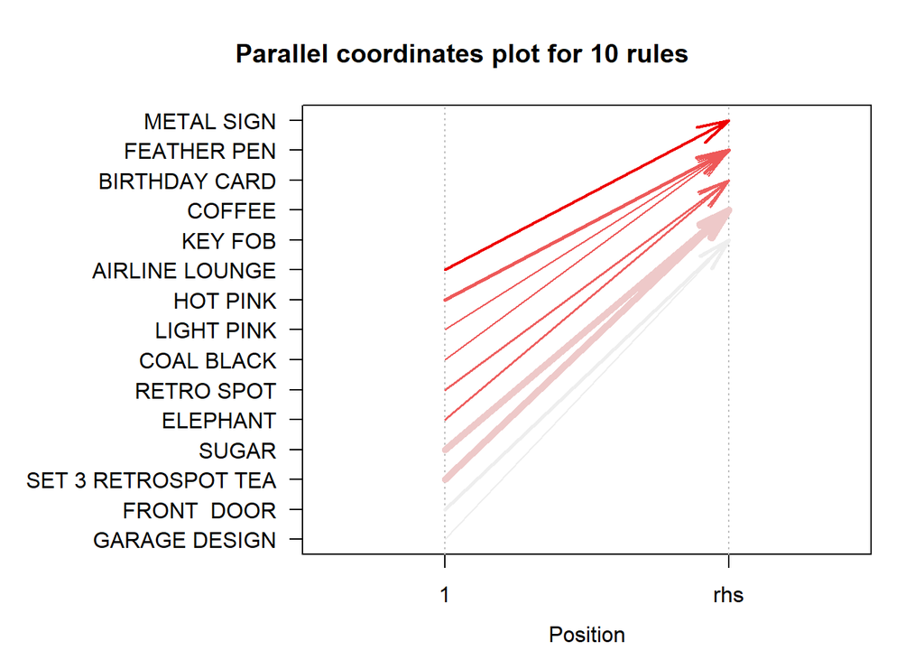

```r
eclatTop10Rules<-head(eclatRules,n=10,by='confidence')
plot(eclatTop10Rules,method ='paracoord')
```

## 5.4 Top 10 items de acuerdo a la confianza usando Apriori

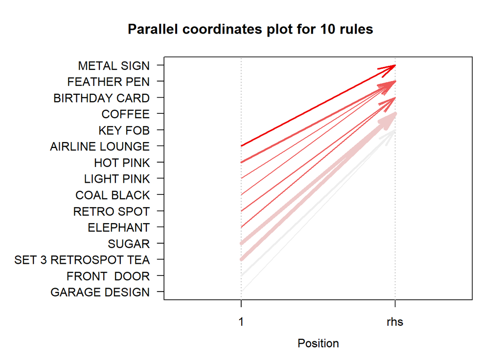

```r
aprioriTop10Rules<-head(aprioriRules,n=10,by='confidence')
plot(aprioriTop10Rules,method ='paracoord')
```

# 6 Desempeño de modelos

# 7 Conclusiones